# Clase Estadística Descriptiva

Hay propiedades que figuran con una superficie total de 0 metros cuadrados, lo cual es imposible. Podemos pensar que son datos faltantes codificados como 0.

Promedio de Superficie

```r
barrios <- unique(datos_filtrados$l3)
barrios <- barrios[!is.na(barrios)]
barrios <- droplevels(barrios)
```

[output not shown]

#6 Explorar el tamaño de una habitación promedio en los distintos barrios. Construir esta variable con el nombre surface_covered / rooms

```r
hab_prom <- c()
for (barrio in barrios){
    hab_prom <- c(hab_prom,mean(datos_filtrados$surface_covered[datos_filtrados$l3==barrio]/
                                  datos_filtrados$rooms[datos_filtrados$l3==barrio], na.rm = T))
}
resumen$Habitacion_promedio <- hab_prom
resumen

barplot(resumen$Habitacion_promedio, names.arg = resumen$Barrio, cex.names = 0.7)
```

[output not shown]

#2. Relación entre el precio y las caracterı́sticas de una propieda. Retener únicamente las propiedades cuyo precio esté en dolares.

```r
datos_filtr_usd <- datos_filtrados[is.element(datos_filtrados$currency,"USD"),]
datos_filtr_usd
```

|  | id | ad_type | start_date | end_date | created_on | lat | lon | l1 | l2 | l3 | l4 | l5 | l6 | rooms | bedrooms | bathrooms | surface_total | surface_covered | price | currency | price_period | title | property_type | operation_type |
| --- | --- | --- | --- | --- | --- | --- | --- | --- | --- | --- | --- | --- | --- | --- | --- | --- | --- | --- | --- | --- | --- | --- | --- | --- |
| 263 | HdjpKrqdwYfH9YU1DKjltg== | Propiedad | 2019-04-14 | 2019-04-15 | 2019-04-14 | -34.62825 | -58.40652 | Argentina | Capital Federal | Boedo | NA | NA | NA | 6 | NA | 2 | 178 | 240 | 500000 | USD | Mensual | Casa - San Telmo | Casa | Venta |
| 343 | oO3WJx+3SP4A9jqBy1sMng== | Propiedad | 2019-04-14 | 2019-04-29 | 2019-04-14 | -34.60377 | -58.38159 | Argentina | Capital Federal | Centro / Microcentro | NA | NA | NA | NA | NA | 2 | 85 | 85 | 127000 | USD | Mensual | Oficina de 1 ambiente en Venta en Centro | Oficina | Venta |
| 388 | KAsKStpJk83O1/BZDPYPHA== | Propiedad | 2019-04-14 | 9999-12-31 | 2019-04-14 | -34.61503 | -58.36297 | Argentina | Capital Federal | Puerto Madero | NA | NA | NA | 4 | NA | 2 | 174 | 174 | 1080000 | USD | Mensual | Torre LUMIERE Excel. dúplex bcon aterr. vista Dique-4 amb coch-Full amenities-Pto Madero | Departamento | Venta |
| 460 | O6YsUCBM8sj80TPJ7ErNjw== | Propiedad | 2019-04-14 | 2019-04-29 | 2019-04-14 | -34.58498 | -58.45421 | Argentina | Capital Federal | Colegiales | NA | NA | NA | 2 | 1 | 1 | 39 | 34 | 85000 | USD | Mensual | Departamento de 2 ambientes en Venta en Colegiales | Departamento | Venta |
| 461 | vgPwaTNV4Fezv42N+1YGhw== | Propiedad | 2019-04-14 | 2019-06-23 | 2019-04-14 | -34.56856 | -58.45135 | Argentina | Capital Federal | Colegiales | NA | NA | NA | 2 | 1 | 1 | 38 | 38 | 105000 | USD | NA | EXCELENTE DEPARTAMENTO 2 AMBIENTES BALCÓN FRANCÉS | Departamento | Venta |
| 470 | /HUjBBQVplbRd2/FuBjfGg== | Propiedad | 2019-04-14 | 2019-08-17 | 2019-04-14 | -34.60946 | -58.36622 | Argentina | Capital Federal | Puerto Madero | NA | NA | NA | 2 | 1 | 1 | 37 | 35 | 900 | USD | NA | Alquiler Departamento 2 amb Paquete. | Departamento | Alquiler temporal |
| 471 | pMLGL7zNdzBCT00EOovuMQ== | Propiedad | 2019-04-14 | 2019-08-07 | 2019-04-14 | -34.61826 | -58.35998 | Argentina | Capital Federal | Puerto Madero | NA | NA | NA | 2 | 1 | 1 | 54 | 50 | 390000 | USD | NA | 2 amb c/ cochera/baulera CON RENTA Torre Onix | Departamento | Venta |
| 532 | pqE1IQmRV8By+htaLzU1og== | Propiedad | 2019-04-14 | 9999-12-31 | 2019-04-14 | -34.57336 | -58.45608 | Argentina | Capital Federal | Colegiales | NA | NA | NA | 3 | 2 | 2 | 70 | 56 | 185000 | USD | NA | 3 ambientes con baño y toilette, cocina -oficce amplia, 2 patios luminoso, APTO CREDITO | Departamento | Venta |
| 543 | 5hddYN+OjnnNt8NW1ShpRg== | Propiedad | 2019-04-14 | 2019-07-10 | 2019-04-14 | -34.61449 | -58.40047 | Argentina | Capital Federal | Centro / Microcentro | NA | NA | NA | 3 | 2 | 1 | 52 | 47 | 92000 | USD | Mensual | DEPARTAMENTO EN VENTA | Departamento | Venta |
| 1350 | WEXcV9kuAws0qJQSlNrPvA== | Propiedad | 2019-05-01 | 2019-06-18 | 2019-05-01 | -34.66342 | -58.49324 | Argentina | Capital Federal | Mataderos | NA | NA | NA | NA | NA | NA | 210 | 1649 | 215000 | USD | Mensual | LOTE EN VENTA | Lote | Venta |

[output cut: 990 more lines]

```r
NA
NA
```

1. Construir la variable fondo, calculada como surface total - surface covered.

```r
datos_filtr_usd$fondo <- datos_filtr_usd$surface_total-datos_filtr_usd$surface_covered
datos_filtr_usd
```

|  | id | ad_type | start_date | end_date | created_on | lat | lon | l1 | l2 | l3 | l4 | l5 | l6 | rooms | bedrooms | bathrooms | surface_total | surface_covered | price | currency | price_period | title | property_type | operation_type | fondo |
| --- | --- | --- | --- | --- | --- | --- | --- | --- | --- | --- | --- | --- | --- | --- | --- | --- | --- | --- | --- | --- | --- | --- | --- | --- | --- |
| 263 | HdjpKrqdwYfH9YU1DKjltg== | Propiedad | 2019-04-14 | 2019-04-15 | 2019-04-14 | -34.62825 | -58.40652 | Argentina | Capital Federal | Boedo | NA | NA | NA | 6 | NA | 2 | 178 | 240 | 500000 | USD | Mensual | Casa - San Telmo | Casa | Venta | -62 |
| 343 | oO3WJx+3SP4A9jqBy1sMng== | Propiedad | 2019-04-14 | 2019-04-29 | 2019-04-14 | -34.60377 | -58.38159 | Argentina | Capital Federal | Centro / Microcentro | NA | NA | NA | NA | NA | 2 | 85 | 85 | 127000 | USD | Mensual | Oficina de 1 ambiente en Venta en Centro | Oficina | Venta | 0 |
| 388 | KAsKStpJk83O1/BZDPYPHA== | Propiedad | 2019-04-14 | 9999-12-31 | 2019-04-14 | -34.61503 | -58.36297 | Argentina | Capital Federal | Puerto Madero | NA | NA | NA | 4 | NA | 2 | 174 | 174 | 1080000 | USD | Mensual | Torre LUMIERE Excel. dúplex bcon aterr. vista Dique-4 amb coch-Full amenities-Pto Madero | Departamento | Venta | 0 |
| 460 | O6YsUCBM8sj80TPJ7ErNjw== | Propiedad | 2019-04-14 | 2019-04-29 | 2019-04-14 | -34.58498 | -58.45421 | Argentina | Capital Federal | Colegiales | NA | NA | NA | 2 | 1 | 1 | 39 | 34 | 85000 | USD | Mensual | Departamento de 2 ambientes en Venta en Colegiales | Departamento | Venta | 5 |
| 461 | vgPwaTNV4Fezv42N+1YGhw== | Propiedad | 2019-04-14 | 2019-06-23 | 2019-04-14 | -34.56856 | -58.45135 | Argentina | Capital Federal | Colegiales | NA | NA | NA | 2 | 1 | 1 | 38 | 38 | 105000 | USD | NA | EXCELENTE DEPARTAMENTO 2 AMBIENTES BALCÓN FRANCÉS | Departamento | Venta | 0 |
| 470 | /HUjBBQVplbRd2/FuBjfGg== | Propiedad | 2019-04-14 | 2019-08-17 | 2019-04-14 | -34.60946 | -58.36622 | Argentina | Capital Federal | Puerto Madero | NA | NA | NA | 2 | 1 | 1 | 37 | 35 | 900 | USD | NA | Alquiler Departamento 2 amb Paquete. | Departamento | Alquiler temporal | 2 |
| 471 | pMLGL7zNdzBCT00EOovuMQ== | Propiedad | 2019-04-14 | 2019-08-07 | 2019-04-14 | -34.61826 | -58.35998 | Argentina | Capital Federal | Puerto Madero | NA | NA | NA | 2 | 1 | 1 | 54 | 50 | 390000 | USD | NA | 2 amb c/ cochera/baulera CON RENTA Torre Onix | Departamento | Venta | 4 |
| 532 | pqE1IQmRV8By+htaLzU1og== | Propiedad | 2019-04-14 | 9999-12-31 | 2019-04-14 | -34.57336 | -58.45608 | Argentina | Capital Federal | Colegiales | NA | NA | NA | 3 | 2 | 2 | 70 | 56 | 185000 | USD | NA | 3 ambientes con baño y toilette, cocina -oficce amplia, 2 patios luminoso, APTO CREDITO | Departamento | Venta | 14 |
| 543 | 5hddYN+OjnnNt8NW1ShpRg== | Propiedad | 2019-04-14 | 2019-07-10 | 2019-04-14 | -34.61449 | -58.40047 | Argentina | Capital Federal | Centro / Microcentro | NA | NA | NA | 3 | 2 | 1 | 52 | 47 | 92000 | USD | Mensual | DEPARTAMENTO EN VENTA | Departamento | Venta | 5 |
| 1350 | WEXcV9kuAws0qJQSlNrPvA== | Propiedad | 2019-05-01 | 2019-06-18 | 2019-05-01 | -34.66342 | -58.49324 | Argentina | Capital Federal | Mataderos | NA | NA | NA | NA | NA | NA | 210 | 1649 | 215000 | USD | Mensual | LOTE EN VENTA | Lote | Venta | -1439 |

[output cut: 990 more lines]

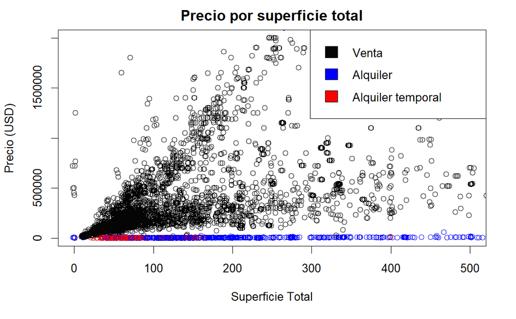

```r
colores=c("gray2", "blue", "red")

datos_filtr_usd$operation_type <- factor(datos_filtr_usd$operation_type, levels = c("Venta", "Alquiler", "Alquiler temporal"))

plot(jitter(datos_filtr_usd$surface_total), jitter(datos_filtr_usd$price), main="Precio por superficie total", type="p",xlab="Superficie Total", ylab="Precio (USD)", xlim = c(0,500), ylim = c(0,2000000),col =colores[datos_filtr_usd$operation_type])
legend("topright",legend=levels(datos_filtr_usd$operation_type), fill=colores)
```

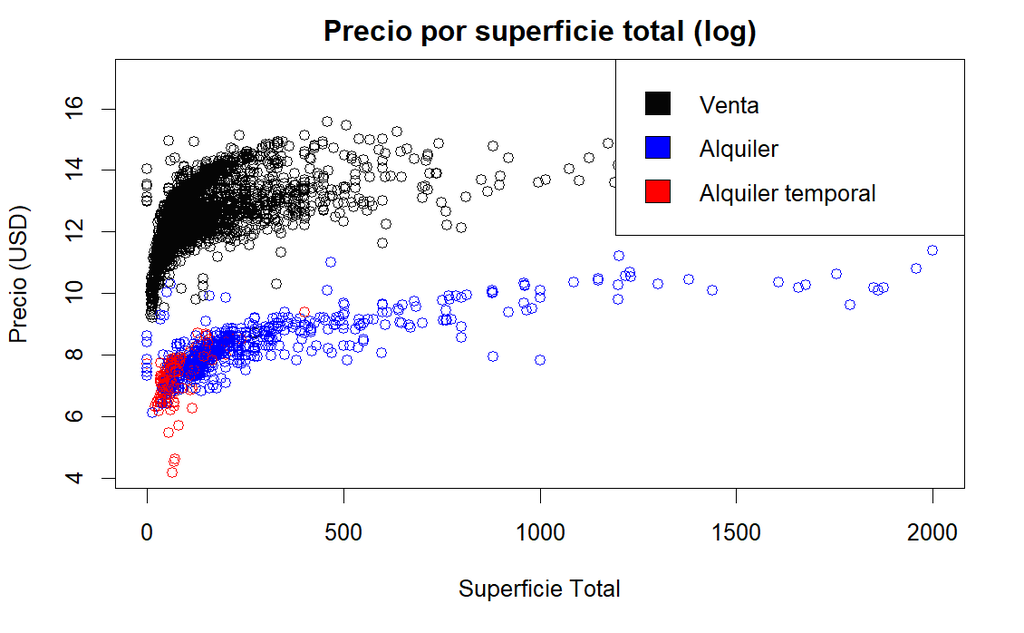

```r
plot(datos_filtr_usd$surface_total, log(datos_filtr_usd$price), main="Precio por superficie total (log)", type="p",xlab="Superficie Total", ylab="Precio (USD)",xlim = c(0,2000),col =colores[datos_filtr_usd$operation_type] )
legend("topright",legend=levels(datos_filtr_usd$operation_type), fill=colores)
```

```r
NA
NA
```

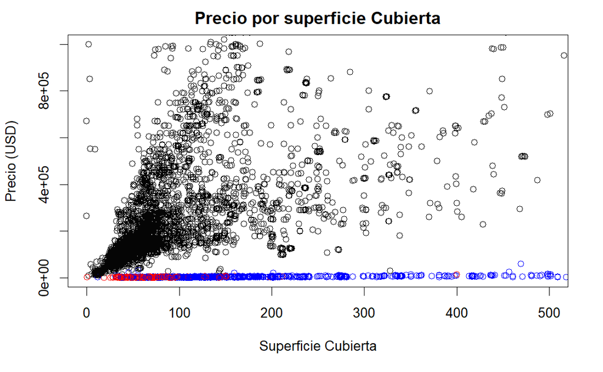

```r
plot(jitter(datos_filtr_usd$surface_covered), jitter(datos_filtr_usd$price), main="Precio por superficie Cubierta", type="p",xlab="Superficie Cubierta", ylab="Precio (USD)", xlim = c(0,500), ylim = c(0,1000000),col =colores[datos_filtr_usd$operation_type])
```

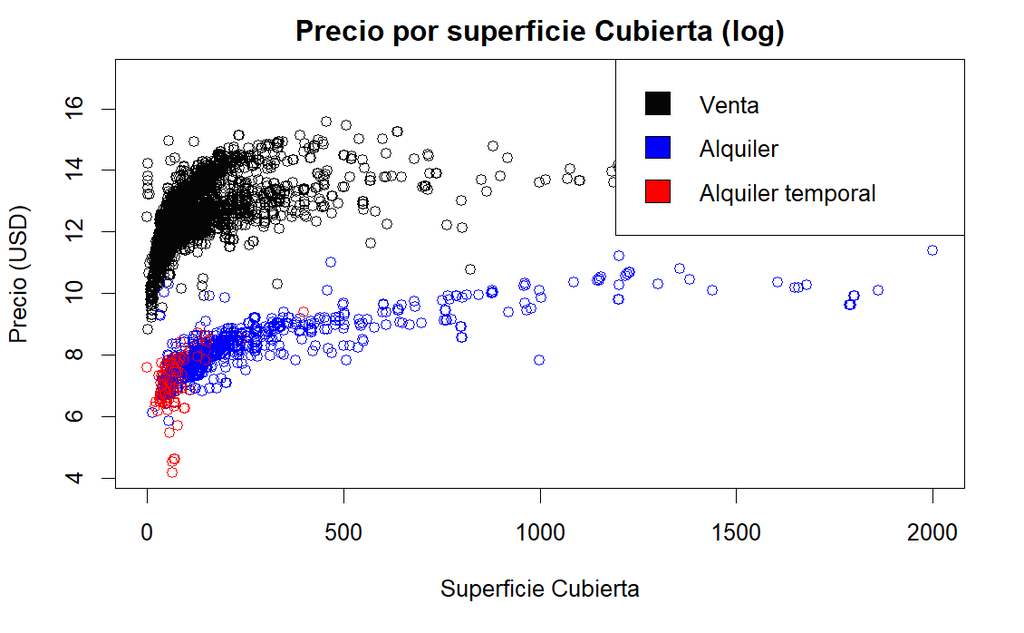

```r
plot(jitter(datos_filtr_usd$surface_covered), log(datos_filtr_usd$price), main="Precio por superficie Cubierta (log)", type="p",xlab="Superficie Cubierta", ylab="Precio (USD)", xlim = c(0,2000),col =colores[datos_filtr_usd$operation_type])
legend("topright",legend=levels(datos_filtr_usd$operation_type), fill=colores)
```

```r
NA
NA
```

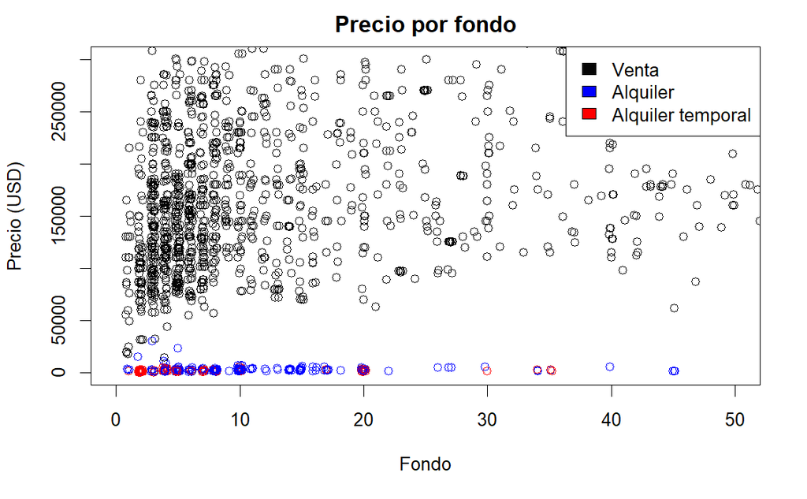

```r
plot(jitter(datos_filtr_usd$fondo[datos_filtr_usd$fondo>0]), jitter(datos_filtr_usd$price[datos_filtr_usd$fondo>0]), main="Precio por fondo", type="p",xlab="Fondo", ylab="Precio (USD)",col =colores[datos_filtr_usd$operation_type[datos_filtr_usd$fondo>0]],xlim=c(0,50),ylim=c(0,300000))
legend("topright",legend=levels(datos_filtr_usd$operation_type[datos_filtr_usd$fondo>0]), fill=colores)
```

[figure not shown]

```r
plot(datos_filtr_usd$fondo[datos_filtr_usd$fondo>0],
     log(datos_filtr_usd$price[datos_filtr_usd$fondo>0]), main="Precio por fondo (log)",
     type="p",xlab="Fondo", ylab="Precio (USD)",
     col=colores[datos_filtr_usd$operation_type[datos_filtr_usd$fondo>0]],
     xlim=c(0,5), ylim=c(0,100000))

legend("topright",legend=levels(datos_filtr_usd$operation_type[datos_filtr_usd$fondo>0]), fill=colores)
```

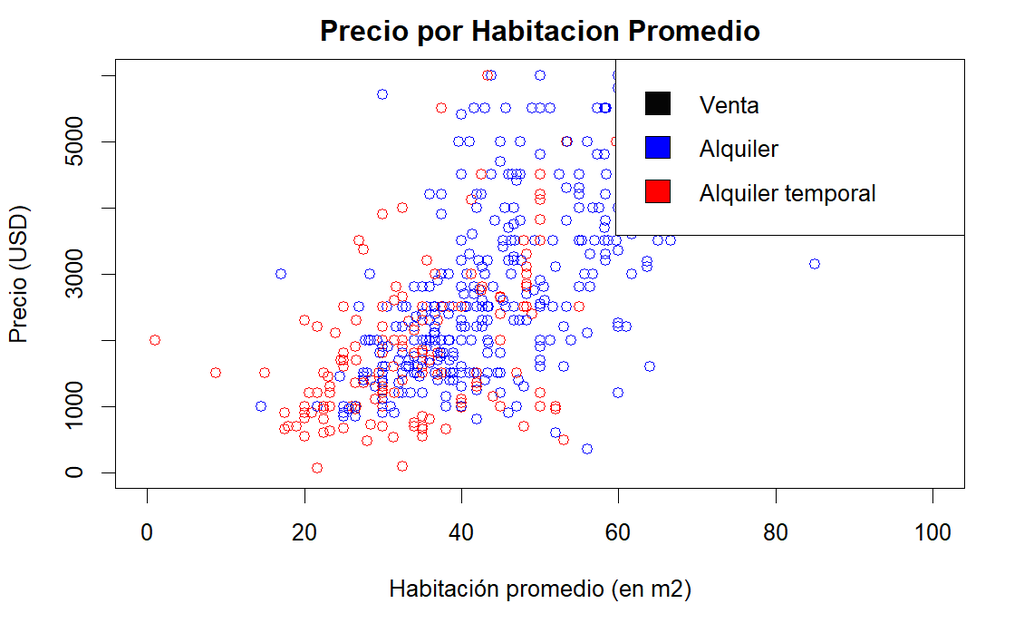

```r
datos_filtr_usd$hab_prom <- datos_filtr_usd$surface_covered/datos_filtr_usd$rooms

plot(datos_filtr_usd$hab_prom, datos_filtr_usd$price, main="Precio por Habitacion Promedio", type="p",xlab="Habitación promedio (en m2)", ylab="Precio (USD)",xlim = c(0,100),ylim = c(0,6000),col =colores[datos_filtr_usd$operation_type])
legend("topright",legend=levels(datos_filtr_usd$operation_type), fill=colores)
```

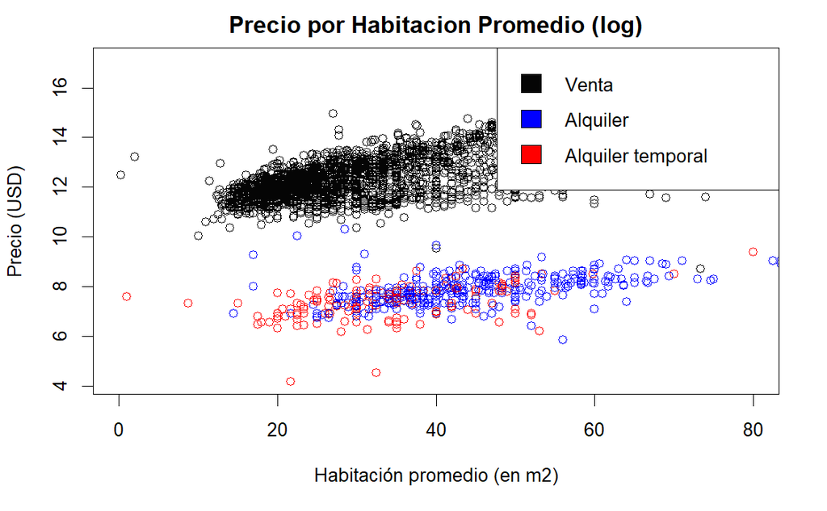

```r
plot(datos_filtr_usd$hab_prom, log(datos_filtr_usd$price), main="Precio por Habitacion Promedio (log)", type="p",xlab="Habitación promedio (en m2)", ylab="Precio (USD)", xlim = c(0,80), col =colores[datos_filtr_usd$operation_type])
legend("topright",legend=levels(datos_filtr_usd$operation_type), fill=colores)
```

```r
NA
NA
```

#3. Explorar el precio en función del tipo de propiedad. Visualizar como se reparten estas propiedades por los distintos barrios, y qué precios tienen.

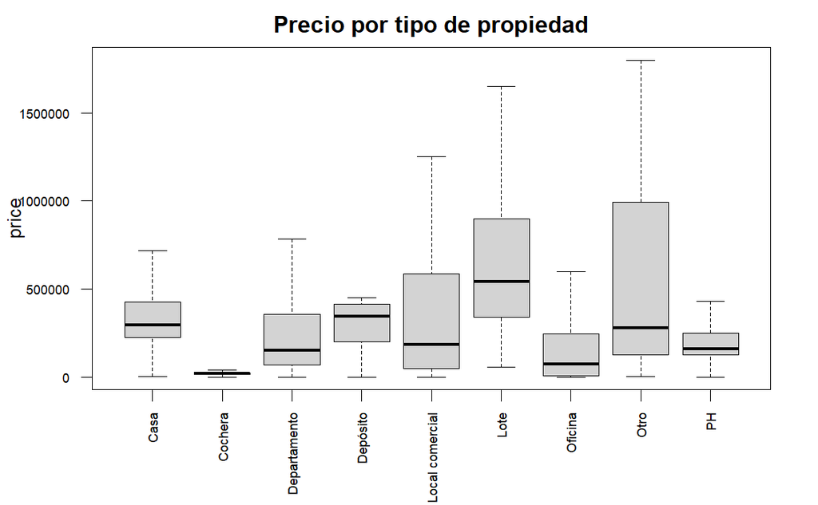

```r
boxplot(price ~ property_type, datos_filtr_usd, pch=18,las=2, outline=FALSE, cex.axis=0.7,xlab="", main="Precio por tipo de propiedad")
```

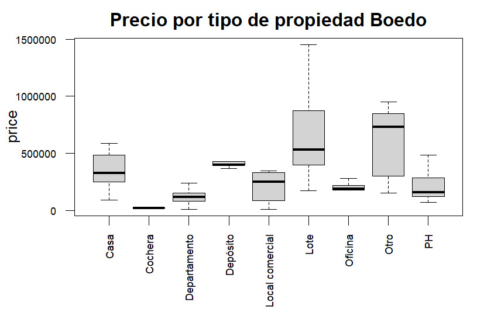

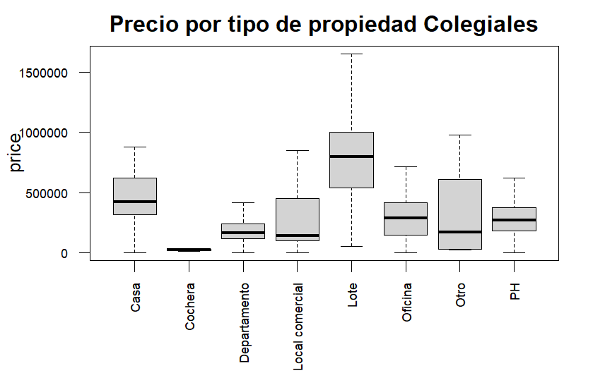

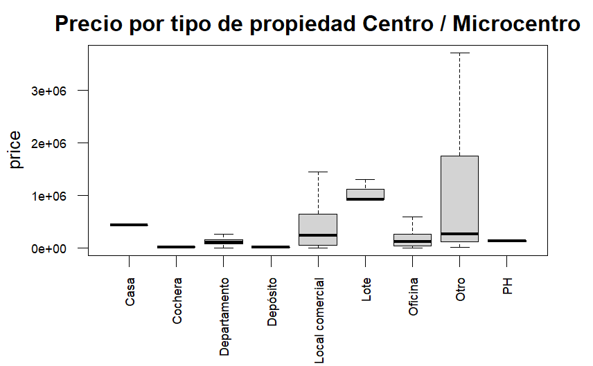

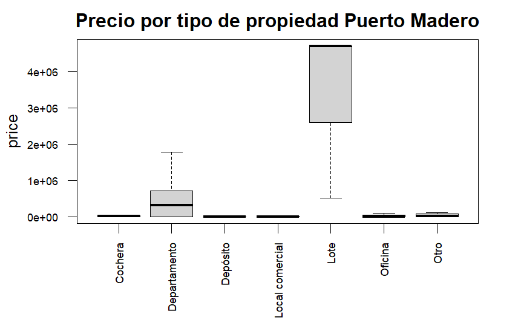

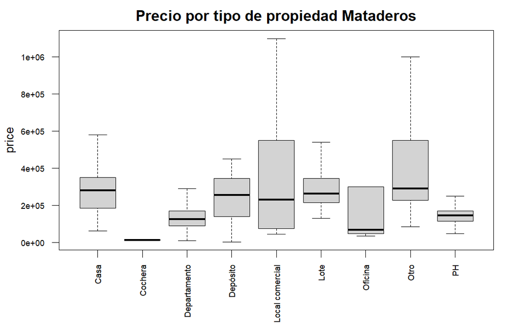

```r
for (barrio in barrios){
  boxplot(price ~ property_type, datos_filtr_usd[datos_filtr_usd$l3==barrio,], pch=18,las=2, outline=FALSE, cex.axis=0.7,xlab="", main=paste("Precio por tipo de propiedad", barrio))
}
```